# Part II - (PISA DATA)

## by (Glendah)

## Student perfomance internationally

> 262631 of the students are given an estimate international grade of 10. This is like 54% of the total students. Fewer students are graded 13, 12 and 7 respectively.

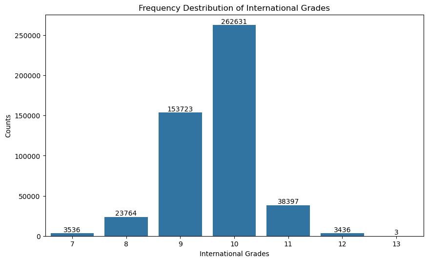

## Equalities experienced by Gender in terms of perfomance

Both gender are equal in terms perfomance, both have a mean of about 450

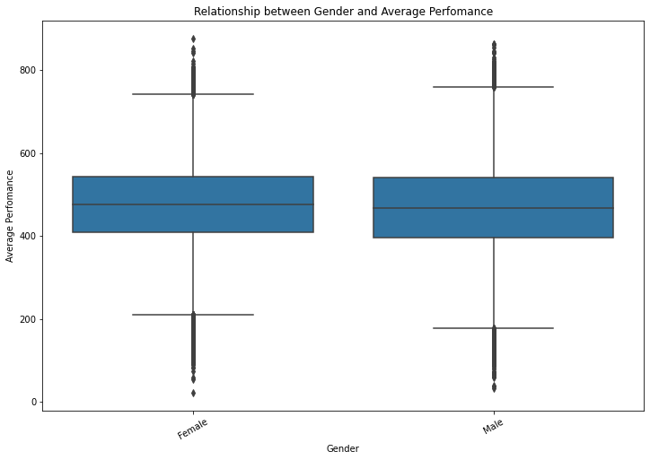

## Students with a parents perfom well

> Students Who have a parent fairly perfom well. In both instances its clear that students who have either of the parent perfom better. But those who dont have a mother seem to perfom very poor than those who dont have a father

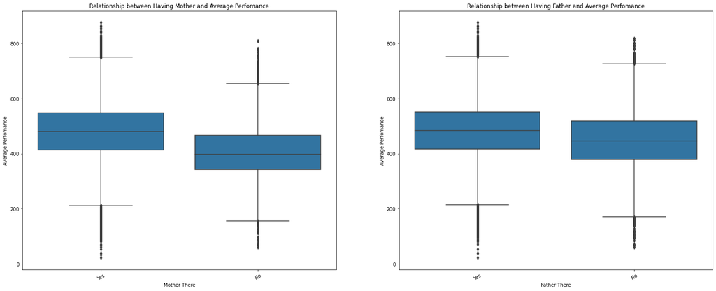